# EDA

```python
import numpy as np
import pandas as pd
import seaborn as sns
import matplotlib.pyplot as plt
```

# Read the data

```python
#Read the csv
df = pd.read_csv('../../../archive/2022/heart_2022_with_nans.csv')
df.head()
```

|  | State | Sex | GeneralHealth | PhysicalHealthDays | MentalHealthDays | LastCheckupTime | PhysicalActivities | SleepHours | RemovedTeeth | HadHeartAttack | ... | HeightInMeters | WeightInKilograms | BMI | AlcoholDrinkers | HIVTesting | FluVaxLast12 | PneumoVaxEver | TetanusLast10Tdap | HighRiskLastYear | CovidPos |
| --- | --- | --- | --- | --- | --- | --- | --- | --- | --- | --- | --- | --- | --- | --- | --- | --- | --- | --- | --- | --- | --- |
| 0 | Alabama | Female | Very good | 0.0 | 0.0 | Within past year (anytime less than 12 months ... | No | 8.0 | NaN | No | ... | NaN | NaN | NaN | No | No | Yes | No | Yes, received tetanus shot but not sure what type | No | No |
| 1 | Alabama | Female | Excellent | 0.0 | 0.0 | NaN | No | 6.0 | NaN | No | ... | 1.60 | 68.04 | 26.57 | No | No | No | No | No, did not receive any tetanus shot in the pa... | No | No |
| 2 | Alabama | Female | Very good | 2.0 | 3.0 | Within past year (anytime less than 12 months ... | Yes | 5.0 | NaN | No | ... | 1.57 | 63.50 | 25.61 | No | No | No | No | NaN | No | Yes |
| 3 | Alabama | Female | Excellent | 0.0 | 0.0 | Within past year (anytime less than 12 months ... | Yes | 7.0 | NaN | No | ... | 1.65 | 63.50 | 23.30 | No | No | Yes | Yes | No, did not receive any tetanus shot in the pa... | No | No |
| 4 | Alabama | Female | Fair | 2.0 | 0.0 | Within past year (anytime less than 12 months ... | Yes | 9.0 | NaN | No | ... | 1.57 | 53.98 | 21.77 | Yes | No | No | Yes | No, did not receive any tetanus shot in the pa... | No | No |

5 rows × 40 columns

Read the info of the dataset

```python
df.info()
```

```
<class 'pandas.core.frame.DataFrame'>
RangeIndex: 445132 entries, 0 to 445131
Data columns (total 40 columns):
 #   Column                     Non-Null Count   Dtype
---  ------                     --------------   -----
 0   State                      445132 non-null  object
 1   Sex                        445132 non-null  object
 2   GeneralHealth              443934 non-null  object
 3   PhysicalHealthDays         434205 non-null  float64
 4   MentalHealthDays           436065 non-null  float64
 5   LastCheckupTime            436824 non-null  object
 6   PhysicalActivities         444039 non-null  object
 7   SleepHours                 439679 non-null  float64
 8   RemovedTeeth               433772 non-null  object
 9   HadHeartAttack             442067 non-null  object
```

[output cut: 32 more lines]

We see that there some null values in the dataset. That is important to know for the later models.

Lets take a look at numerical values

```python
df.describe()
```

|  | PhysicalHealthDays | MentalHealthDays | SleepHours | HeightInMeters | WeightInKilograms | BMI |
| --- | --- | --- | --- | --- | --- | --- |
| count | 434205.000000 | 436065.000000 | 439679.000000 | 416480.000000 | 403054.000000 | 396326.000000 |
| mean | 4.347919 | 4.382649 | 7.022983 | 1.702691 | 83.074470 | 28.529842 |
| std | 8.688912 | 8.387475 | 1.502425 | 0.107177 | 21.448173 | 6.554889 |
| min | 0.000000 | 0.000000 | 1.000000 | 0.910000 | 22.680000 | 12.020000 |
| 25% | 0.000000 | 0.000000 | 6.000000 | 1.630000 | 68.040000 | 24.130000 |
| 50% | 0.000000 | 0.000000 | 7.000000 | 1.700000 | 80.740000 | 27.440000 |
| 75% | 3.000000 | 5.000000 | 8.000000 | 1.780000 | 95.250000 | 31.750000 |
| max | 30.000000 | 30.000000 | 24.000000 | 2.410000 | 292.570000 | 99.640000 |

This shows the mean, std, min, max ...

Lets sum the null values for each column

```python
df.isnull().sum()
```

```
State                            0
Sex                              0
GeneralHealth                 1198
PhysicalHealthDays           10927
MentalHealthDays              9067
LastCheckupTime               8308
PhysicalActivities            1093
SleepHours                    5453
RemovedTeeth                 11360
HadHeartAttack                3065
HadAngina                     4405
HadStroke                     1557
HadAsthma                     1773
HadSkinCancer                 3143
HadCOPD                       2219
HadDepressiveDisorder         2812
HadKidneyDisease              1926
HadArthritis                  2633
HadDiabetes                   1087
DeafOrHardOfHearing          20647
BlindOrVisionDifficulty      21564
DifficultyConcentrating      24240
DifficultyWalking            24012
DifficultyDressingBathing    23915
DifficultyErrands            25656
SmokerStatus                 35462
ECigaretteUsage              35660
ChestScan                    56046
RaceEthnicityCategory        14057
AgeCategory                   9079
HeightInMeters               28652
WeightInKilograms            42078
BMI                          48806
AlcoholDrinkers              46574
HIVTesting                   66127
FluVaxLast12                 47121
PneumoVaxEver                77040
TetanusLast10Tdap            82516
HighRiskLastYear             50623
CovidPos                     50764
dtype: int64
```

We can see that there are some null values for a lot of columns. We need to take care of those for the training later.

Now lets have a look at duplicates and delete them from the dataset.

```python
int(df.duplicated().sum())
```

```
157
```

```python
df = df.drop_duplicates()
df
```

|  | State | Sex | GeneralHealth | PhysicalHealthDays | MentalHealthDays | LastCheckupTime | PhysicalActivities | SleepHours | RemovedTeeth | HadHeartAttack | ... | HeightInMeters | WeightInKilograms | BMI | AlcoholDrinkers | HIVTesting | FluVaxLast12 | PneumoVaxEver | TetanusLast10Tdap | HighRiskLastYear | CovidPos |
| --- | --- | --- | --- | --- | --- | --- | --- | --- | --- | --- | --- | --- | --- | --- | --- | --- | --- | --- | --- | --- | --- |
| 0 | Alabama | Female | Very good | 0.0 | 0.0 | Within past year (anytime less than 12 months ... | No | 8.0 | NaN | No | ... | NaN | NaN | NaN | No | No | Yes | No | Yes, received tetanus shot but not sure what type | No | No |
| 1 | Alabama | Female | Excellent | 0.0 | 0.0 | NaN | No | 6.0 | NaN | No | ... | 1.60 | 68.04 | 26.57 | No | No | No | No | No, did not receive any tetanus shot in the pa... | No | No |
| 2 | Alabama | Female | Very good | 2.0 | 3.0 | Within past year (anytime less than 12 months ... | Yes | 5.0 | NaN | No | ... | 1.57 | 63.50 | 25.61 | No | No | No | No | NaN | No | Yes |
| 3 | Alabama | Female | Excellent | 0.0 | 0.0 | Within past year (anytime less than 12 months ... | Yes | 7.0 | NaN | No | ... | 1.65 | 63.50 | 23.30 | No | No | Yes | Yes | No, did not receive any tetanus shot in the pa... | No | No |
| 4 | Alabama | Female | Fair | 2.0 | 0.0 | Within past year (anytime less than 12 months ... | Yes | 9.0 | NaN | No | ... | 1.57 | 53.98 | 21.77 | Yes | No | No | Yes | No, did not receive any tetanus shot in the pa... | No | No |
| ... | ... | ... | ... | ... | ... | ... | ... | ... | ... | ... | ... | ... | ... | ... | ... | ... | ... | ... | ... | ... | ... |
| 445127 | Virgin Islands | Female | Good | 0.0 | 3.0 | Within past 2 years (1 year but less than 2 ye... | Yes | 6.0 | None of them | No | ... | 1.65 | 69.85 | 25.63 | NaN | Yes | No | No | No, did not receive any tetanus shot in the pa... | No | Yes |
| 445128 | Virgin Islands | Female | Excellent | 2.0 | 2.0 | Within past year (anytime less than 12 months ... | Yes | 7.0 | None of them | No | ... | 1.70 | 83.01 | 28.66 | No | Yes | Yes | No | Yes, received tetanus shot but not sure what type | No | No |
| 445129 | Virgin Islands | Female | Poor | 30.0 | 30.0 | 5 or more years ago | No | 5.0 | 1 to 5 | No | ... | 1.70 | 49.90 | 17.23 | NaN | No | No | No | No, did not receive any tetanus shot in the pa... | No | No |
| 445130 | Virgin Islands | Male | Very good | 0.0 | 0.0 | Within past year (anytime less than 12 months ... | No | 5.0 | None of them | Yes | ... | 1.83 | 108.86 | 32.55 | No | Yes | Yes | Yes | No, did not receive any tetanus shot in the pa... | No | Yes |
| 445131 | Virgin Islands | Male | Very good | 0.0 | 1.0 | NaN | Yes | 5.0 | None of them | No | ... | 1.68 | 63.50 | 22.60 | Yes | No | No | No | Yes, received tetanus shot but not sure what type | No | No |

444975 rows × 40 columns

Now we want to work on categorical columns so that they can be better used for visualizations. An example would be the age column since it is a string and can therfore not ordered directly. This counts for many other columns as well. So we print each non numerical column to see the values and we will then step by step get rid of them.

```python
non_numeric_columns = df.select_dtypes(exclude=['number']).columns

# Return values of non numerical columns
def printUniqueValues(df,column):
    return f'Column: {column} Values: {df[column].unique()}'
def categorical_into_numerocal_yes_no(df,column):
    return  df[column].apply(lambda val: 0 if( val == 'No') else 1 if (val == 'Yes') else  val)
for column in non_numeric_columns:
    row = printUniqueValues(df, column)
    print(row)
```

```
Column: State Values: ['Alabama' 'Alaska' 'Arizona' 'Arkansas' 'California' 'Colorado'
 'Connecticut' 'Delaware' 'District of Columbia' 'Florida' 'Georgia'
 'Hawaii' 'Idaho' 'Illinois' 'Indiana' 'Iowa' 'Kansas' 'Kentucky'
 'Louisiana' 'Maine' 'Maryland' 'Massachusetts' 'Michigan' 'Minnesota'
 'Mississippi' 'Missouri' 'Montana' 'Nebraska' 'Nevada' 'New Hampshire'
 'New Jersey' 'New Mexico' 'New York' 'North Carolina' 'North Dakota'
 'Ohio' 'Oklahoma' 'Oregon' 'Pennsylvania' 'Rhode Island' 'South Carolina'
 'South Dakota' 'Tennessee' 'Texas' 'Utah' 'Vermont' 'Virginia'
 'Washington' 'West Virginia' 'Wisconsin' 'Wyoming' 'Guam' 'Puerto Rico'
 'Virgin Islands']
Column: Sex Values: ['Female' 'Male']
Column: GeneralHealth Values: ['Very good' 'Excellent' 'Fair' 'Poor' 'Good' nan]
Column: LastCheckupTime Values: ['Within past year (anytime less than 12 months ago)' nan
 'Within past 2 years (1 year but less than 2 years ago)'
 'Within past 5 years (2 years but less than 5 years ago)'
 '5 or more years ago']
Column: PhysicalActivities Values: ['No' 'Yes' nan]
Column: RemovedTeeth Values: [nan 'None of them' '1 to 5' '6 or more, but not all' 'All']
Column: HadHeartAttack Values: ['No' 'Yes' nan]
Column: HadAngina Values: ['No' 'Yes' nan]
Column: HadStroke Values: ['No' 'Yes' nan]
Column: HadAsthma Values: ['No' 'Yes' nan]
Column: HadSkinCancer Values: ['No' 'Yes' nan]
Column: HadCOPD Values: ['No' 'Yes' nan]
Column: HadDepressiveDisorder Values: ['No' 'Yes' nan]
Column: HadKidneyDisease Values: ['No' 'Yes' nan]
Column: HadArthritis Values: ['No' 'Yes' nan]
Column: HadDiabetes Values: ['Yes' 'No' 'No, pre-diabetes or borderline diabetes' nan
 'Yes, but only during pregnancy (female)']
Column: DeafOrHardOfHearing Values: ['No' nan 'Yes']
Column: BlindOrVisionDifficulty Values: ['No' 'Yes' nan]
Column: DifficultyConcentrating Values: ['No' nan 'Yes']
Column: DifficultyWalking Values: ['No' 'Yes' nan]
Column: DifficultyDressingBathing Values: ['No' nan 'Yes']
Column: DifficultyErrands Values: ['No' 'Yes' nan]
Column: SmokerStatus Values: ['Never smoked' 'Current smoker - now smokes some days' 'Former smoker'
 nan 'Current smoker - now smokes every day']
Column: ECigaretteUsage Values: ['Not at all (right now)' 'Never used e-cigarettes in my entire life' nan
 'Use them every day' 'Use them some days']
Column: ChestScan Values: ['No' 'Yes' nan]
Column: RaceEthnicityCategory Values: ['White only, Non-Hispanic' 'Black only, Non-Hispanic'
 'Other race only, Non-Hispanic' 'Multiracial, Non-Hispanic' nan
 'Hispanic']
Column: AgeCategory Values: ['Age 80 or older' 'Age 55 to 59' nan 'Age 40 to 44' 'Age 75 to 79'
 'Age 70 to 74' 'Age 65 to 69' 'Age 60 to 64' 'Age 50 to 54'
 'Age 45 to 49' 'Age 35 to 39' 'Age 25 to 29' 'Age 30 to 34'
 'Age 18 to 24']
Column: AlcoholDrinkers Values: ['No' 'Yes' nan]
Column: HIVTesting Values: ['No' 'Yes' nan]
Column: FluVaxLast12 Values: ['Yes' 'No' nan]
Column: PneumoVaxEver Values: ['No' 'Yes' nan]
Column: TetanusLast10Tdap Values: ['Yes, received tetanus shot but not sure what type'
 'No, did not receive any tetanus shot in the past 10 years' nan
 'Yes, received Tdap' 'Yes, received tetanus shot, but not Tdap']
Column: HighRiskLastYear Values: ['No' nan 'Yes']
Column: CovidPos Values: ['No' 'Yes' nan
 'Tested positive using home test without a health professional']
```

Now each column will get numerical values for the different categories.

```python
df.loc[:,'Sex_n'] = df['Sex'].apply(lambda val: 0 if( val == 'Male') else 1 ) # 0 if male 1 if female
df.loc[:,'LastCheckupTime_n'] = df['LastCheckupTime'].apply( lambda val: 0 if (val == 'Within past year (anytime less than 12 months ago)')
                                                            else 1 if (val == 'Within past 2 years (1 year but less than 2 years ago)')
                                                            else 2 if (val == 'Within past 5 years (2 years but less than 5 years ago)')
                                                            else 3 if (val ==  '5 or more years ago')
                                                            else val)
df.loc[:,'RemovedTeeth_n'] = df['RemovedTeeth'].apply(lambda val: 0 if (val == 'None of them')
                                                        else 1 if (val == '1 to 5')
                                                        else 2 if (val == '6 or more, but not all' )
                                                        else 3 if (val == 'All')
                                                        else val)
df.loc[:,'GeneralHealth_n'] = df['GeneralHealth'].apply(lambda val: 0 if val == 'Poor'
                                                          else 1 if val == 'Fair'
                                                          else 2 if val == 'Good'
                                                          else 3 if val == 'Very good'
                                                          else 4 if val == 'Excellent'
                                                          else val)
df.loc[:,'CovidPos_n'] = df['CovidPos'].apply(lambda val: 0 if (val == 'No')
                                                else 1 if (val == 'Tested positive using home test without a health professional')
                                                else 2 if (val == 'Yes')
                                                else val)
df.loc[:,'TetanusLast10Tdap_n'] = df['TetanusLast10Tdap'].apply(lambda val: 0 if (val == 'Yes, received Tdap')
                                                                else 1 if (val == 'Yes, received tetanus shot, but not Tdap' )
                                                                else 2 if (val == 'Yes, received tetanus shot but not sure what type')
                                                                else 3 if (val == 'No, did not receive any tetanus shot in the past 10 years')
                                                                else val)
df.loc[:,'AgeCategory_n'] = df['AgeCategory'].apply(lambda val: 18 if val == 'Age 18 to 24'
                                                          else 25 if val == 'Age 25 to 29'
                                                          else 30 if val == 'Age 30 to 34'
                                                          else 35 if val == 'Age 35 to 39'
                                                          else 40 if val == 'Age 40 to 44'
                                                          else 45 if val == 'Age 45 to 49'
                                                          else 50 if val == 'Age 50 to 54'
                                                          else 55 if val == 'Age 55 to 59'
                                                          else 60 if val == 'Age 60 to 64'
                                                          else 65 if val == 'Age 65 to 69'
                                                          else 70 if val == 'Age 70 to 74'
                                                          else 75 if val == 'Age 75 to 79'
                                                          else 80 if val == 'Age 80 or older'
                                                          else val) # Age into numerical category based on start age of range so 18 to 24 will be 18
df.loc[:,'HadDiabetes_n'] = df['HadDiabetes'].apply(lambda val: 0 if val == 'No'
                                                          else 1 if val == 'No, pre-diabetes or borderline diabetes'
                                                          else 2 if val == 'Yes, but only during pregnancy (female)'
                                                          else 3 if val == 'Yes'
                                                          else val) # scale from 0 to 3 based on value
df.loc[:,'SmokerStatus_n'] = df['SmokerStatus'].apply(lambda val: 0 if val == 'Never smoked'
                                                          else 1 if val == 'Former smoker'
                                                          else 2 if val == 'Current smoker - now smokes some days'
                                                          else 3 if val == 'Current smoker - now smokes every day'
                                                          else val) # scale from 0 to 4 based on value
df.loc[:,'ECigaretteUsage_n'] = df['ECigaretteUsage'].apply(lambda val: 0 if val == 'Never used e-cigarettes in my entire life'
                                                          else 1 if val == 'Not at all (right now)'
                                                          else 2 if val == 'Use them some days'
                                                          else 3 if val == 'Use them every day'
                                                          else val) # scale from 0 to 4 based on value

for column in non_numeric_columns:
    unique_values = set(df[column].dropna().unique())
    if unique_values == {'Yes', 'No'} and df[column].isna().any():
       df.loc[:,f'{column}_n'] = categorical_into_numerocal_yes_no(df,column)
```

```python
df
```

|  | State | Sex | GeneralHealth | PhysicalHealthDays | MentalHealthDays | LastCheckupTime | PhysicalActivities | SleepHours | RemovedTeeth | HadHeartAttack | ... | DifficultyConcentrating_n | DifficultyWalking_n | DifficultyDressingBathing_n | DifficultyErrands_n | ChestScan_n | AlcoholDrinkers_n | HIVTesting_n | FluVaxLast12_n | PneumoVaxEver_n | HighRiskLastYear_n |
| --- | --- | --- | --- | --- | --- | --- | --- | --- | --- | --- | --- | --- | --- | --- | --- | --- | --- | --- | --- | --- | --- |
| 0 | Alabama | Female | Very good | 0.0 | 0.0 | Within past year (anytime less than 12 months ... | No | 8.0 | NaN | No | ... | 0.0 | 0.0 | 0.0 | 0.0 | 0.0 | 0.0 | 0.0 | 1.0 | 0.0 | 0.0 |
| 1 | Alabama | Female | Excellent | 0.0 | 0.0 | NaN | No | 6.0 | NaN | No | ... | 0.0 | 0.0 | 0.0 | 0.0 | 0.0 | 0.0 | 0.0 | 0.0 | 0.0 | 0.0 |
| 2 | Alabama | Female | Very good | 2.0 | 3.0 | Within past year (anytime less than 12 months ... | Yes | 5.0 | NaN | No | ... | 0.0 | 0.0 | 0.0 | 0.0 | 0.0 | 0.0 | 0.0 | 0.0 | 0.0 | 0.0 |
| 3 | Alabama | Female | Excellent | 0.0 | 0.0 | Within past year (anytime less than 12 months ... | Yes | 7.0 | NaN | No | ... | 0.0 | 0.0 | 0.0 | 0.0 | 1.0 | 0.0 | 0.0 | 1.0 | 1.0 | 0.0 |
| 4 | Alabama | Female | Fair | 2.0 | 0.0 | Within past year (anytime less than 12 months ... | Yes | 9.0 | NaN | No | ... | 0.0 | 0.0 | 0.0 | 0.0 | 1.0 | 1.0 | 0.0 | 0.0 | 1.0 | 0.0 |
| ... | ... | ... | ... | ... | ... | ... | ... | ... | ... | ... | ... | ... | ... | ... | ... | ... | ... | ... | ... | ... | ... |
| 445127 | Virgin Islands | Female | Good | 0.0 | 3.0 | Within past 2 years (1 year but less than 2 ye... | Yes | 6.0 | None of them | No | ... | 0.0 | 0.0 | 0.0 | 0.0 | 1.0 | NaN | 1.0 | 0.0 | 0.0 | 0.0 |
| 445128 | Virgin Islands | Female | Excellent | 2.0 | 2.0 | Within past year (anytime less than 12 months ... | Yes | 7.0 | None of them | No | ... | 0.0 | 0.0 | 0.0 | 0.0 | 0.0 | 0.0 | 1.0 | 1.0 | 0.0 | 0.0 |
| 445129 | Virgin Islands | Female | Poor | 30.0 | 30.0 | 5 or more years ago | No | 5.0 | 1 to 5 | No | ... | NaN | 0.0 | 0.0 | 0.0 | NaN | NaN | 0.0 | 0.0 | 0.0 | 0.0 |
| 445130 | Virgin Islands | Male | Very good | 0.0 | 0.0 | Within past year (anytime less than 12 months ... | No | 5.0 | None of them | Yes | ... | 0.0 | 0.0 | 0.0 | 0.0 | 1.0 | 0.0 | 1.0 | 1.0 | 1.0 | 0.0 |
| 445131 | Virgin Islands | Male | Very good | 0.0 | 1.0 | NaN | Yes | 5.0 | None of them | No | ... | 1.0 | 1.0 | 0.0 | 0.0 | 1.0 | 1.0 | 0.0 | 0.0 | 0.0 | 0.0 |

444975 rows × 72 columns

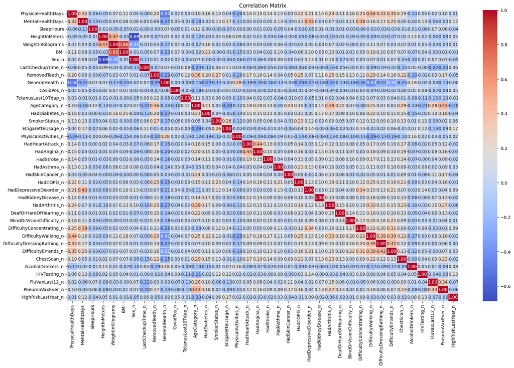

```python
only_numeric_df = df.select_dtypes(include='number')
correlation_matrix = only_numeric_df.corr()

plt.figure(figsize=(20, 12))

sns.heatmap(correlation_matrix, annot=True, cmap='coolwarm', fmt=".2f", linewidths=0.5)
plt.title("Correlation Matrix")
plt.show()
```

The correlation matrix shows the corr between each numerical column. We especially take a look at the correlation of the HadHeartAttack_n column. Unfortunately only the HadAngina column seems to have a stronger linear relationship with HadHeartAttack_n. There are some columns that have a lighter linear relationship like the Age, PhisicalHealthDays, RemovedTeeth, Diabetes, Stroke, COPD and a few more. However we exptected to see some more stronger relationships.

Now lets have a look at some visualizations. At first lets take a look at the gender distribution

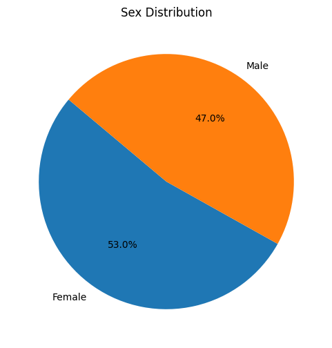

```python
sex_counts = df['Sex'].value_counts()

# Plot the pie chart
plt.figure(figsize=(6, 6))
plt.pie(sex_counts, labels=sex_counts.index, autopct='%1.1f%%', startangle=140)
plt.title('Sex Distribution')
plt.show()
```

We can see that the distribution between the genders is nearly 50/50. So it can represent both genders.

The next two figures show the distribution of the HadHeartAttack column in general and per gender.

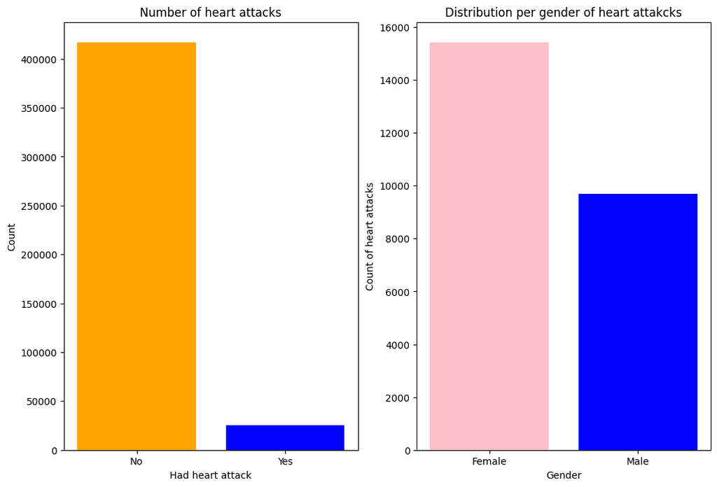

```python
heart_attack_counts_per_gender = df.groupby('Sex_n')['HadHeartAttack_n'].sum()
count_heart_attakcks = df['HadHeartAttack'].value_counts()

plt.figure(figsize=(12,8))
plt.subplot(1,2,1)
plt.bar(count_heart_attakcks.index,count_heart_attakcks.values,color=['orange','blue'])
plt.xlabel('Had heart attack')
plt.ylabel('Count')
plt.title('Number of heart attacks')

plt.subplot(1,2,2)
plt.bar(df['Sex'].unique(),heart_attack_counts_per_gender, color=['pink','blue'])
plt.xlabel('Gender')
plt.ylabel('Count of heart attacks')
plt.title('Distribution per gender of heart attakcks')

plt.show()
```

Lets take a look at some other numerical column and their distribution.

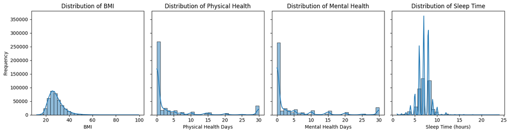

```python
fig, axes = plt.subplots(1, 4, figsize=(15, 4), sharey=True)
# Plot for BMI
sns.histplot(df['BMI'], bins=30, kde=True, ax=axes[0])
axes[0].set_title("Distribution of BMI")
axes[0].set_xlabel("BMI")
axes[0].set_ylabel("Frequency")

# Plot for PhysicalHealth
sns.histplot(df['PhysicalHealthDays'], bins=30, kde=True, ax=axes[1])
axes[1].set_title("Distribution of Physical Health")
axes[1].set_xlabel("Physical Health Days")

# Plot for MentalHealth
sns.histplot(df['MentalHealthDays'], bins=30, kde=True, ax=axes[2])
axes[2].set_title("Distribution of Mental Health")
axes[2].set_xlabel("Mental Health Days")

# Plot for SleepTime
sns.histplot(df['SleepHours'], bins=30, kde=True, ax=axes[3])
axes[3].set_title("Distribution of Sleep Time")
axes[3].set_xlabel("Sleep Time (hours)")

plt.tight_layout()
plt.show()
```

The BMI figure shows that most of the people in the dataset have a BMI between 20-40. However there are some with a slighter higher value.

On the right hand side we can see that most people sleep aroun 6-9 hours.

The next visualization shows the age and gender on the x-axis and the number of heart attacks and anginas.

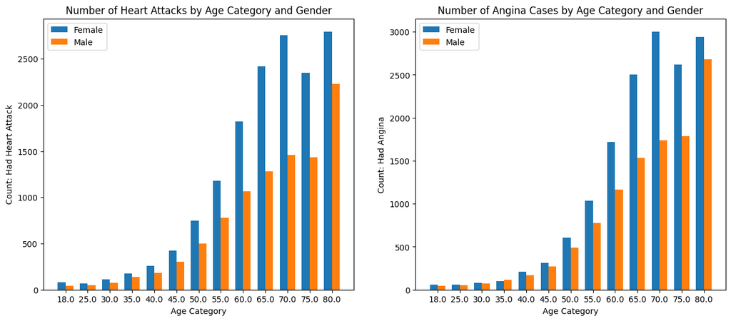

```python
# Grouping heart attack data by age category and gender and calculating the sums
heart_attack_counts = df.groupby(['AgeCategory_n', 'Sex_n'])['HadHeartAttack_n'].sum().unstack()

# Create the plot
age_categories = heart_attack_counts.index
bar_width = 0.35  # Width of the bars

# Positions of the bars for the two genders
index = np.arange(len(age_categories))
plt.figure(figsize=(15,6))
plt.subplot(1,2,1)

# Bars for male and female heart attack cases per age group
plt.bar(index, heart_attack_counts[0], bar_width, label='Female')
plt.bar(index + bar_width, heart_attack_counts[1], bar_width, label='Male')

# Axis labels and title
plt.xlabel('Age Category')
plt.ylabel('Count: Had Heart Attack')
plt.title('Number of Heart Attacks by Age Category and Gender')
plt.xticks(index + bar_width / 2, age_categories)  # Center alignment for age category labels
plt.legend()

plt.subplot(1,2,2)

# Grouping angina data by age category and gender and calculating the sums
angina_counts = df.groupby(['AgeCategory_n', 'Sex_n'])['HadAngina_n'].sum().unstack()

# Create the plot
age_categories2 = angina_counts.index
bar_width = 0.35  # Width of the bars

# Positions of the bars for the two genders
index2 = np.arange(len(age_categories2))

# Bars for male and female angina cases per age group
plt.bar(index2, angina_counts[0], bar_width, label='Female')
plt.bar(index2 + bar_width, angina_counts[1], bar_width, label='Male')

# Axis labels and title
plt.xlabel('Age Category')
plt.ylabel('Count: Had Angina')
plt.title('Number of Angina Cases by Age Category and Gender')
plt.xticks(index2 + bar_width / 2, age_categories2)  # Center alignment for age category labels
plt.legend()

plt.show()
```

Another interesting column to look at could be the number of heart attacks per smoker category.

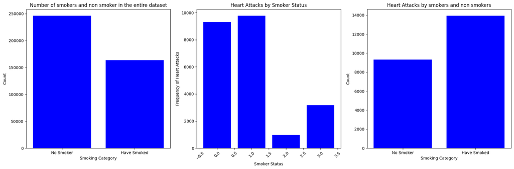

```python
# Group heart attack data by smoker status
count_heart_attack_per_smoker_group = df.groupby('SmokerStatus_n')['HadHeartAttack_n'].sum()

# Count values for "no smoker" and "have smoked" only for those who had a heart attack
value_no_smoker_ha = ((df['SmokerStatus_n'] == 0) & (df['HadHeartAttack_n'] == 1)).sum()
value_have_smoked_ha = ((df['SmokerStatus_n'] >= 1) & (df['HadHeartAttack_n'] == 1)).sum()

value_no_smoker = (df['SmokerStatus_n'] == 0).sum()
value_have_smoked = (df['SmokerStatus_n'] >= 1).sum()

# Create the figure and subplots
plt.figure(figsize=(18, 6))

# First plot: Heart attacks per smoker group
plt.subplot(1, 3, 1)
plt.bar(['No Smoker', 'Have Smoked'], [value_no_smoker, value_have_smoked], color='blue')
plt.xlabel('Smoking Category')
plt.ylabel('Count')
plt.title('Number of smokers and non smoker in the entire dataset')

plt.subplot(1, 3, 2)
plt.bar(count_heart_attack_per_smoker_group.index, count_heart_attack_per_smoker_group.values, color='blue')
plt.xlabel('Smoker Status')
plt.ylabel('Frequency of Heart Attacks')
plt.title('Heart Attacks by Smoker Status')
plt.xticks(rotation=45)

# Second plot: Counts of "no smoker" and "have smoked"
plt.subplot(1, 3, 3)
plt.bar(['No Smoker', 'Have Smoked'], [value_no_smoker_ha, value_have_smoked_ha], color='blue')
plt.xlabel('Smoking Category')
plt.ylabel('Count')
plt.title('Heart Attacks by smokers and non smokers')

# Show the plots
plt.tight_layout()
plt.show()
```

On the left hand side we can see that there are much more non smokers in the dataset. So this is not really balanced.

The figure in the middle is not really as expected. There are a lot of cases of heartattacks for people who dont smoke (value 0). Every other bar represent people who have smoked (value 1), smoke irregular (value 2) or smoke everyday (value 3). We expected to have more cases for value 2 and 3. However if you would make a harder line between 0 and 1-3, it would show that there are more heart attacks for people who have smoked at some point. This can be seen on the right hand side.

It seems that there is a reltionship between smokers and heart attacks. However we expected a stronger one.

Now we take a look at the BMI. The BMI is converted into 4 groups underweight, Normal weight, overweight and obseity. The number of heart attacks per category will be shown.

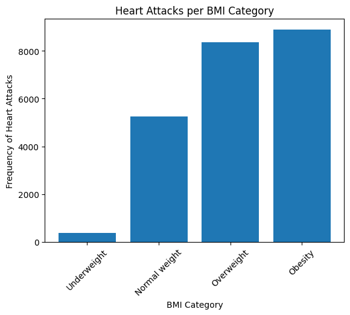

```python
df['BMI_categorised'] = df['BMI'].apply(lambda val: 'Underweight' if val <= 18.5
                                                    else 'Normal weight' if val <= 24.9
                                                    else 'Overweight' if val <= 29.9
                                                    else 'Obesity' if val >= 30
                                                    else 'Unknown')

bmi_order = ['Underweight', 'Normal weight', 'Overweight', 'Obesity']

df['BMI_categorised'] = pd.Categorical(df['BMI_categorised'], categories=bmi_order, ordered=True)

heart_attacks_per_BMI_category = df.groupby('BMI_categorised',observed = True)['HadHeartAttack_n'].sum()

plt.bar(heart_attacks_per_BMI_category.index, heart_attacks_per_BMI_category.values)
plt.xlabel('BMI Category')
plt.ylabel('Frequency of Heart Attacks')
plt.title('Heart Attacks per BMI Category')
plt.xticks(rotation=45)
plt.show()
```

The figure above clearly shows that the number of heart attacks increases for people with a higher BMI. Especially for the category overweight and obseity.

Now we move on to the predicitve challange. This will be done in a seperate notebook. That is why certain imports and coloumn transfomrations are done again.